# NBA Salaries With Machine Learning Models

3/11

## Outline

In this presentation, we will do the following…

- Explain our data set.
- Showcase our basic data visualizations (Simple Linear Regression, Parallel Slopes, Multiple Linear Model with Interaction)
- Review our Caret Package Models and Cross Validated results
- Review our GAM/Polynomial Models and Cross Validated results
- Brief Conclusion

## Our Data

## Data

- NBA statistics and salaries for 2022-2023 season
- Our goal is to try to estimate salaries based on categorical and numeric variables.
- Many of the statistics (total of around 50) provided for players are “obscure” (not interpretable for most people, even basketball fans)
- We chose specific statistics that are interpretable/showed correlation to salary
- Important Note: Salary is extremely difficult to predict. Quantitative statistics cannot be the only measure of player salaries
  - player image, country of origin, background, social media presence, sports media coverage, etc.

## Linear Regression Models

## Simple Linear Regression Model

- Simple Linear Regression Model
  - Points as the explanatory numeric variable
  - Trying to predict salary

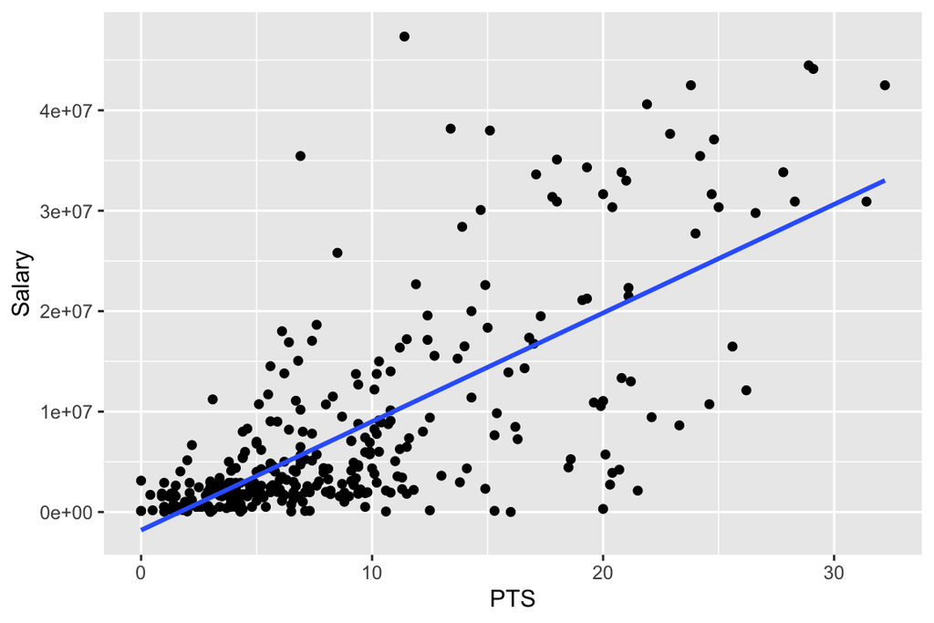

## Parallel Slopes Model

- Parallel Slopes Regression Model
  - Points (numeric) and Position (categorical)
  - Predicting Salary

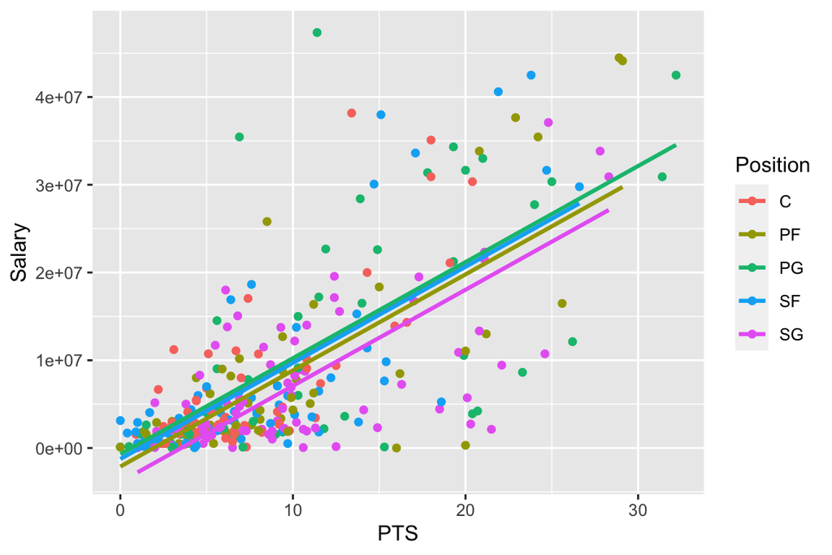

## Multiple Linear Regression Model

- Multiple Linear Regression Model w/ Interaction
  - PTS*Position, Significant p-values with Interaction
  - Again, predicting Salary

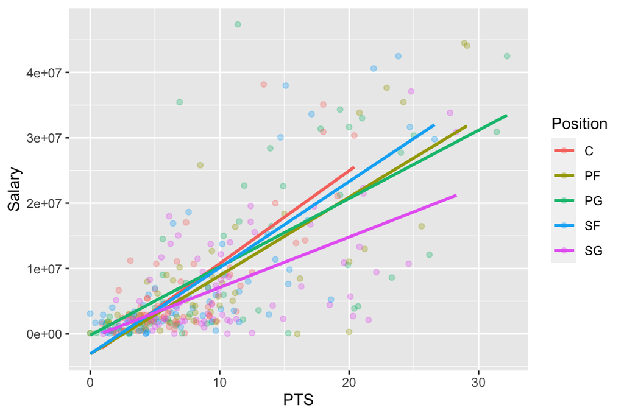

## Caret Package Models

## Regression Trees Pt1 - Complexity x RMSE

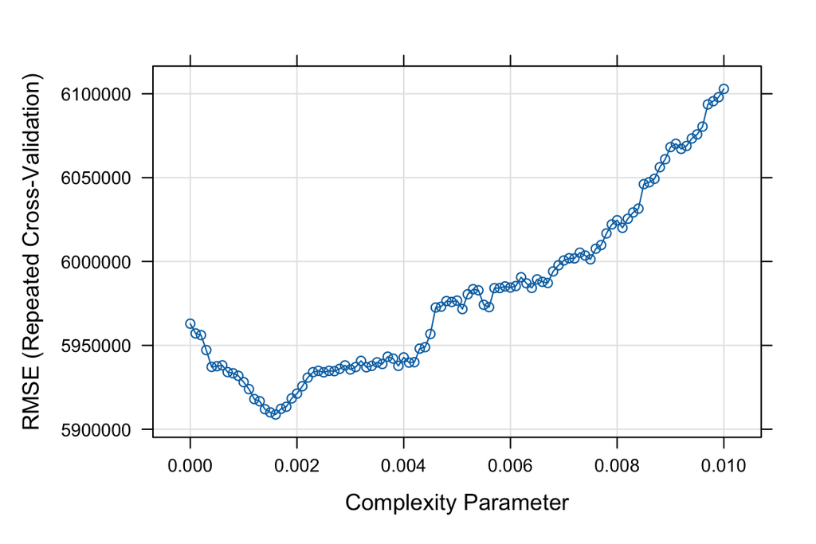

- train(Salary ~ Position + Team + Age + PTS + PER + WS + OBPM)

## Regression Trees Pt2 - Tree

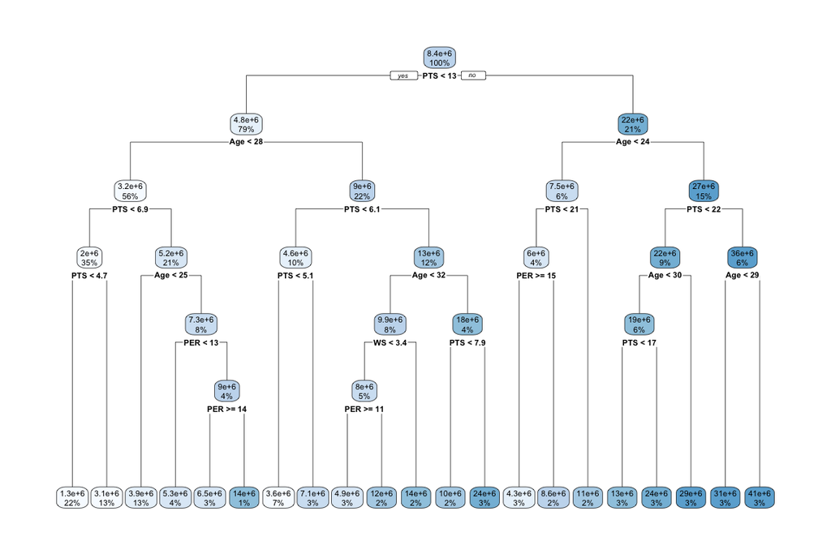

## Regression Trees Pt3 - Cross Validation Results

```
##        cp    RMSE  Rsquared     MAE  RMSESD RsquaredSD    MAESD
## 17 0.0016 5908762 0.6957081 3736796 1089236  0.1083776 534506.3
```

- Note: RMSE & r-squared

## Multiple Linear Model Cross Validation

```
##   intercept    RMSE  Rsquared     MAE   RMSESD RsquaredSD    MAESD
## 1      TRUE 6365014 0.6481738 4628864 661924.8 0.05762886 339415.4
```

- Variables Used: Age & Points
  - Only variables that consistently had significant p-values

## GAM & Polynomial Models

## GAM Model 1

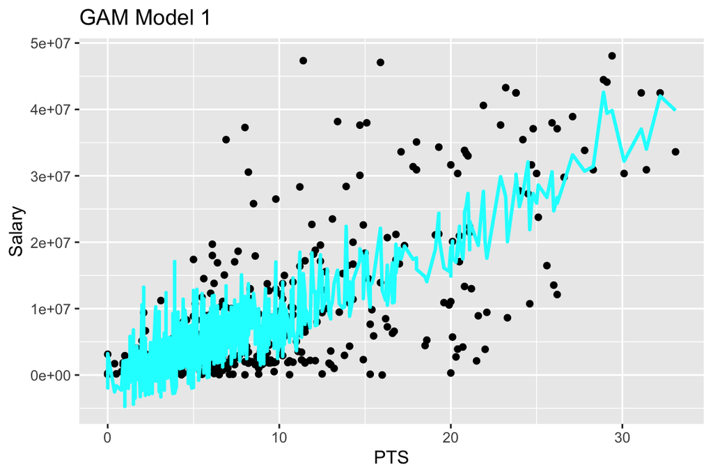

- mod_gam = gam(Salary ~ s(PTS) + Age, data = salary)
  - Interpretation: s(PTS) using spline-based, Age treated as a linear predictor, Risk of Overfitting

## Cross Validated Results: GAM Model 1

```
##   select method    RMSE  Rsquared     MAE   RMSESD RsquaredSD    MAESD
## 1  FALSE GCV.Cp 6238792 0.6630162 4438240 682359.5 0.06052310 341401.4
## 2   TRUE GCV.Cp 6230128 0.6635708 4429822 681562.8 0.06075497 347458.7
```

## GAM Model 2

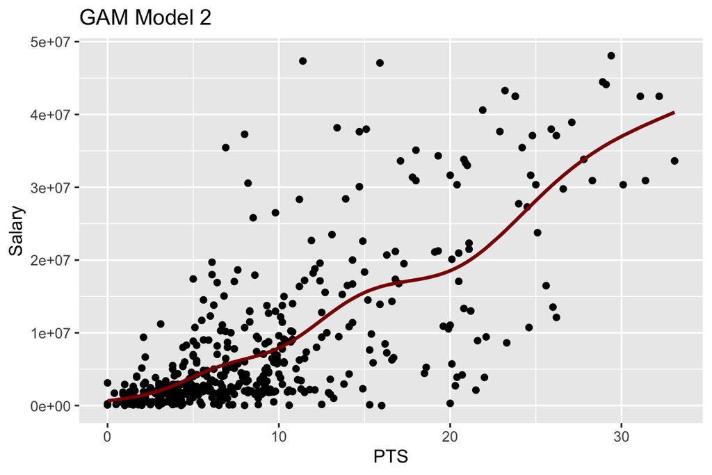

- mod_gam2 <- gam(Salary ~ s(PTS), data = salary)
  - s(PTS): Using PTS as spline-based, less risk of overfitting than using both PTS and Age as spline-based

## Cross Validated Results: GAM Model 2

```
##   select method    RMSE  Rsquared     MAE   RMSESD RsquaredSD    MAESD
## 1  FALSE GCV.Cp 7334875 0.5356286 4820861 859345.8 0.07969144 442097.5
## 2   TRUE GCV.Cp 7307106 0.5385997 4794078 855310.8 0.07943537 435074.1
```

## Polynomial Models – PTS & Salary

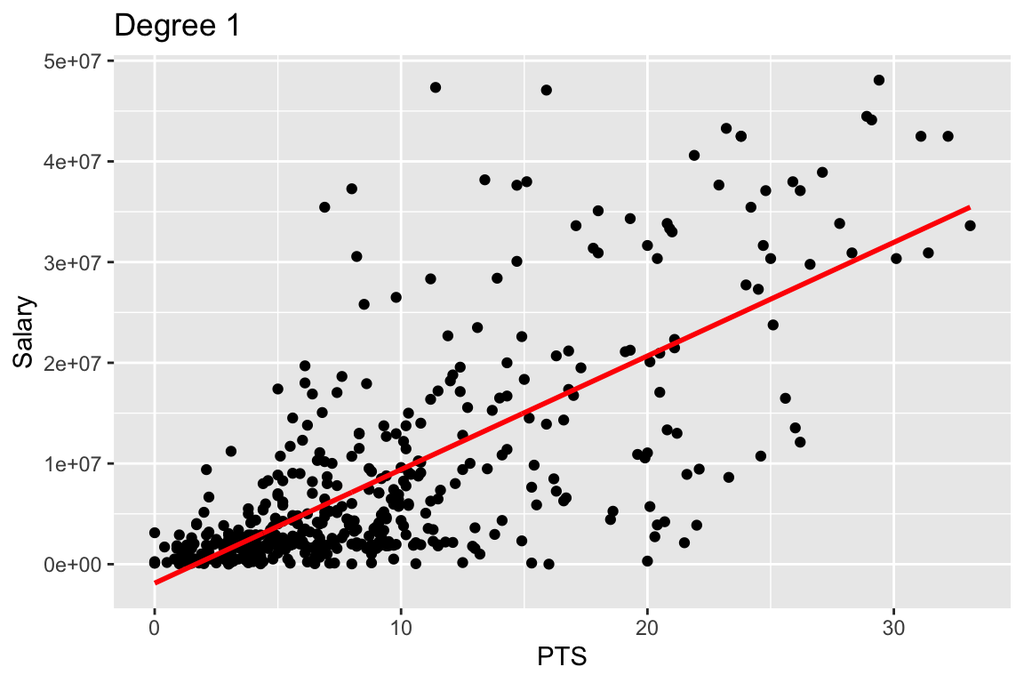

## Degree 2

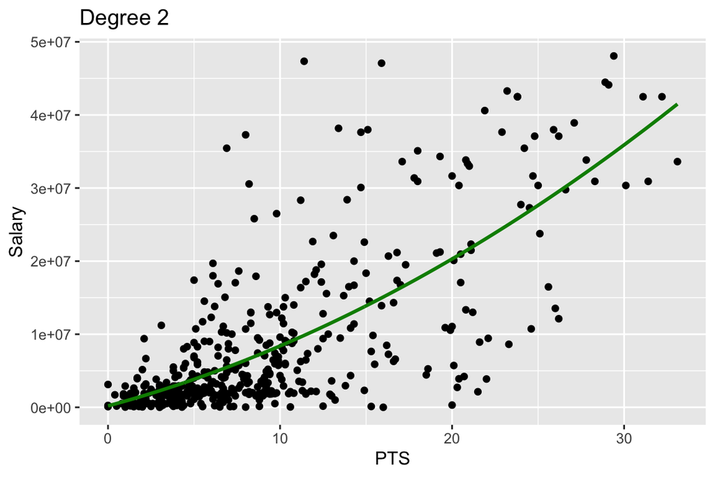

## Degree 3: Cubic

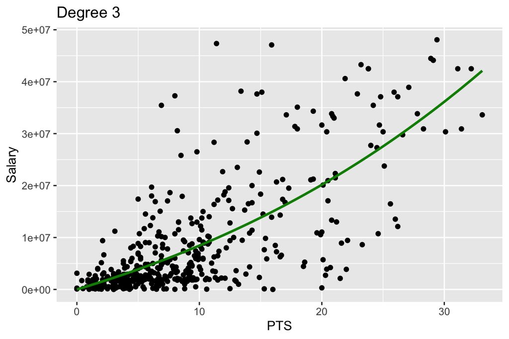

## Degree 5

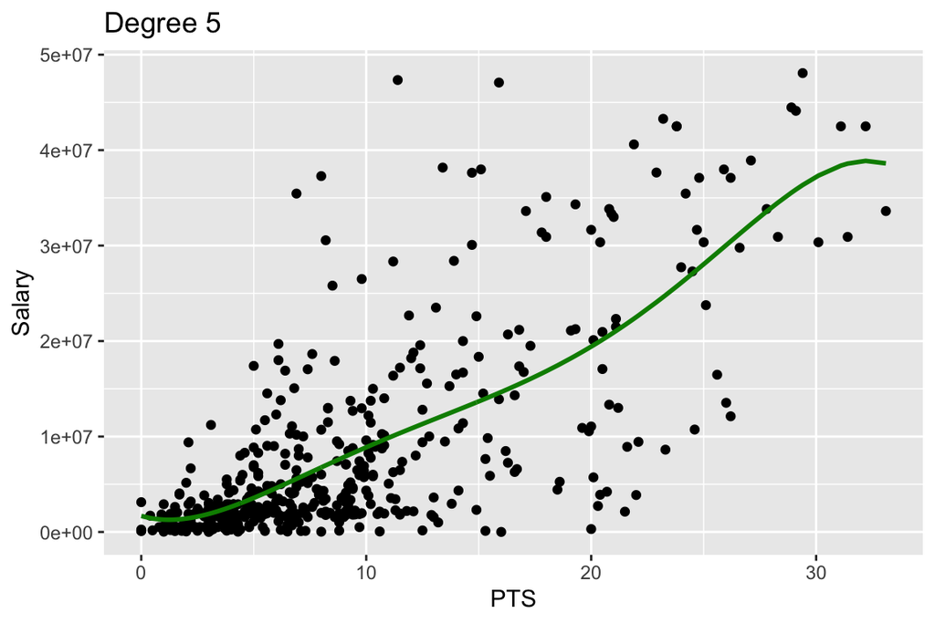

## Degree 10

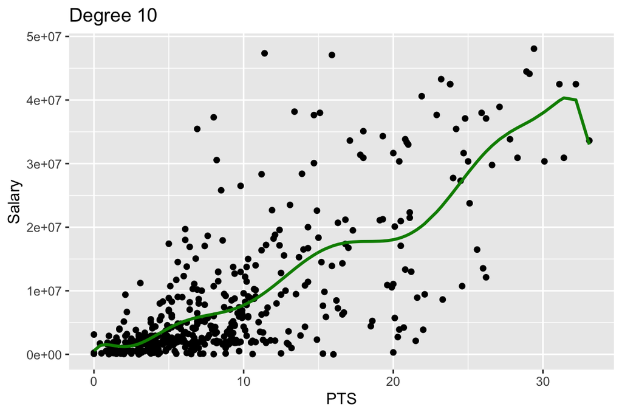

## Significance

```
##
## Call:
## lm(formula = Salary ~ poly(PTS, 5), data = salary)
##
## Residuals:
##       Min        1Q    Median        3Q       Max
## -19557109  -3224725   -837962   1785500  37081745
##
## Coefficients:
##                Estimate Std. Error t value Pr(>|t|)
## (Intercept)     8416599     337387  24.946  < 2e-16 ***
## poly(PTS, 5)1 168188704    7290998  23.068  < 2e-16 ***
## poly(PTS, 5)2  23130677    7290998   3.172  0.00161 **
## poly(PTS, 5)3   1788690    7290998   0.245  0.80631
## poly(PTS, 5)4    809088    7290998   0.111  0.91169
## poly(PTS, 5)5 -10043314    7290998  -1.377  0.16903
## ---
## Signif. codes:  0 '***' 0.001 '**' 0.01 '*' 0.05 '.' 0.1 ' ' 1
##
## Residual standard error: 7291000 on 461 degrees of freedom
## Multiple R-squared:  0.5414, Adjusted R-squared:  0.5364
## F-statistic: 108.8 on 5 and 461 DF,  p-value: < 2.2e-16
```

## Cross Validated Results

```
##   intercept    RMSE  Rsquared     MAE   RMSESD RsquaredSD    MAESD
## 1      TRUE 7258159 0.5445287 4757083 875337.1 0.08067987 437049.9
```